# Exploratory Data Analysis & Data Cleaning

## Recall the Research Question

Given the data sets suffer from a lot of **missing follow-up data**, we focused our main research question on building classifier models for patients **baseline diagnosis** using patients **brain imaging data from their first visits, adjusting for basic demographic information.**

## Exploration on ADNI Data Base

**(1)** The ADNI data base collected the data from **3 phases** of the longitudinal study:

- ADNI1
- ADNIGO
- ADNI2

Each phase applied **different protocol**, and to make sure all subjects were undergone the same protocol, we **focused our project on ADNI1**, which has the **largest amount of participant**.

**(2)** ADNI1 includes **4 subsets of data**:

- clinical data
- genetics data
- MRI data
- PET image data

We choose to **focus on MRI data**, because PET data has much less information than MRI data.

## How We Construct Our Data Sets

**Step1:** We started with the **adnimerge table** *(ADNIMERGE.csv)* which merges together several of the key variables from various case report forms and biomarker lab summaries across all the 3 ADNI protocols. We :

- Explored demographic distribution
- Compared data qualities among the 3 phases
- Tracked longitudinal scores
- Plotted distribution of the 6 imaging variables.

After all the basic exploration, **4 demographic features** and **6 imaging features** were left, which constitute the **base set**. We built our **base models** on this base set.

**Step2:** Then we **merged brain imaging features from UPENN Hierarchical Parcellation of MRI data** set *(UPENNROI_MARS_06_01_16.csv)* into the base set. We:

- Checked collinearity of the predictors
- Cleaned the hierarchical variables
- Combined symmetric features

Then we built our **final models** based on this **compositional set**.

## Descriptions of Data Sets & Cleaning Strategy

### 1. Adnimerge *(ADNIMERGE.csv)*

#### (1) subset selection

The Adnimerge data set collected the **important features from 3 phases of the longitudinal study and 4 sections of data base** (selected by exports). Each phase applied **different protocol**, and to make sure all subjects were undergone the same protocol, we **focused our project on ADNI1**, which has the **largest amount of participant**.

Adnimerge data set stores **multiple visit records for every single subject**. Since the data suffers from **a lot of missing follow-up data**, we only kept subjects’ **first visit records**, based on which to classify patients baseline diagnosis. Given the race distribution *(Figure 1)*, we find the **majority of the ADNI1 population is white**. Considering the possible obstacles (too many **complex but rare categories**; race is **highly unbalanced**) in model fitting, we decided to restrict our data set to **only White subjects**

Figure 1. **Race Composition of patiecnts in ADNI1**

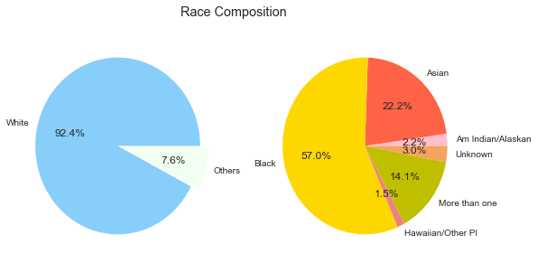

```python
plt.figure(figsize=(9,4.5))
plt.suptitle("Race Composition")
plt.subplot(1,2,1)
plt.pie([race_count[-1],sum(race_count[0:6])],labels=["White","Others"],explode = (0,0.1),\
        colors = [ 'lightskyblue',"honeydew"],\
       autopct='%1.1f%%')
plt.subplot(1,2,2)
plt.pie(race_count[0:6],labels=race_list[0:6],colors=['pink', "tomato",'gold', 'lightcoral',"y","sandybrown"],\
       autopct='%1.1f%%');
```

#### (2) outcome selection

We selected **patients’ categorical diagnosis at baseline*(“DX_bl”)*** as the outcome variable, because it has only 3 **categories *(CN, LMCI, AD)*** and is more reliable.

We also explored the **MMSE at baseline** as a surrogate outcome and may attempt to build up a model for this variable into a model as well. The ideal case is to identify patients’ subgroups based on the shape of their MMSE trajectories. Fixed effect longitudinal model might be attempted and individual level coefficients extracted from the mixed effect longitudinal model will be utilized for patient stratification. The trajectories of MMSE over time are generated using 35 randomly selected patients. Due to the **imbalance and insufficient variation** in MMSE, we decided to **shelve the modeling of this variable.** *(Figure 2)*

Figure 2. **Traceplots of MMSE over Time(N=35)**

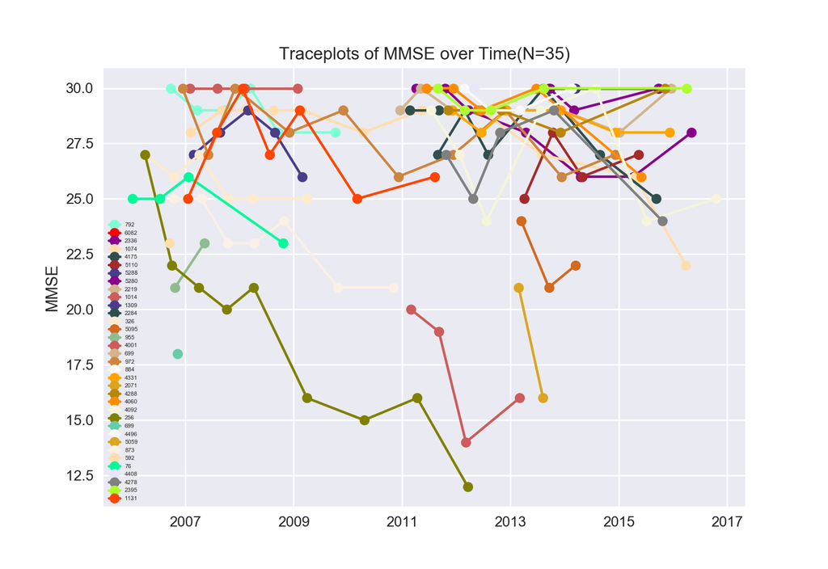

```python
random.seed(31)
for pid in random_pid:
    profile=dxdict[pid].dropna(axis=0,how="any")
    plt.plot_date(profile["EXAMDATE"],profile["MMSE"],fmt="-",marker="o",label=pid,color=random.choice(list(colors.cnames.values())))
plt.legend(prop={'size': 4})
plt.ylabel("MMSE")
plt.title("Traceplots of MMSE over Time(N=35)");
```

#### (3)features selection

**Demographic features** were inspected as they are potential confounders. The distribution of three subgroups stratified by gender is visualized by the bar plot, from which we gain evidence to keep **sex** included in all models. *(Figure 3)*

Figure 3. **Baseline Diagnosis stratified by gender**

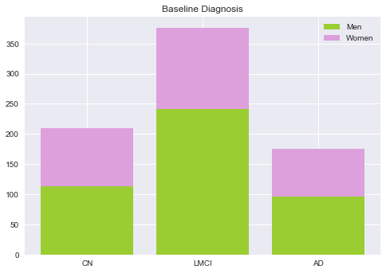

```python
p1=plt.bar([1,2,3],mens,color="yellowgreen")
p2=plt.bar([1,2,3],womens,bottom=mens,color="plum")
plt.xticks([1,2,3],["CN","LMCI","AD"])
plt.title("Baseline Diagnosis")
plt.legend((p1[0],p2[0]),("Men","Women"));
```

Figure 4. **Distribution of MRI Brain Imaging Variables among 3 Baseline Diagnoses**

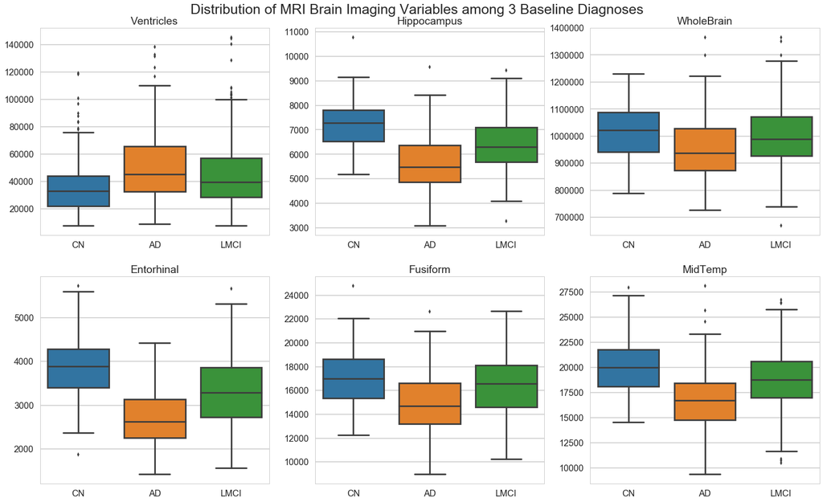

```python
plt.figure(figsize = (25,15))
plt.suptitle("Distribution of MRI Brain Imaging Variables among 3 Baseline Diagnoses", fontsize=25, y = 0.92)

for i,p in enumerate(predictors):
    plt.subplot(len(predictors)/3,3,i+1)
    a = sns.boxplot(x = 'DX_bl', y=p, data= dfbase)
    a.set_xlabel("")
    a.set_ylabel("")
    a.set_title(p)
```

To further investigate the **relationships of these 6 features** of interest, and the **capability of each predictor to distinguish the three classes**, we drew the **pair plot** of them *(Figure 5)*. From the plot we concluded that:

- (1) **Hippocampus** distinguish the three levels best, followed by **Entorhinal**(however, Entorhinal does distinguish AD from NC well).
- (2) There is **no evidence** that any 2 of the 6 features have **special interaction**.

Thus, we have good reason to keep all of them.

Figure 5. **Initial Exploration of 6 General Brain Imaging Variables**

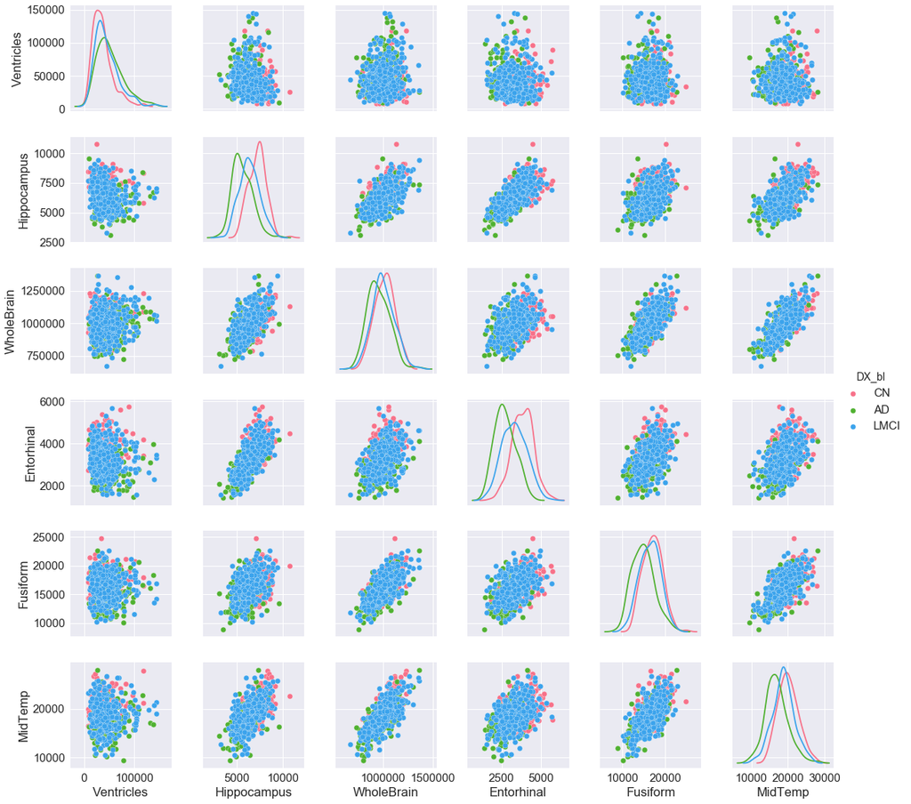

```python
sb.set(font_scale=1.5)
sb.pairplot(pairplot_set, hue="DX_bl", size=2.5, diag_kind='kde',palette="husl");
#plt.suptitle("Initial Exploration of 6 General Brain Imaging Variables");
```

### 2. UPENN - Hierarchical Parcellation of MRI using multi-atlas labeling methods *(UPENNROI_MARS_06_01_16.csv)*

We use the brain imaging features from UPENN Hierarchical Parcellation of MRI data set (UPENN). UPENN dataset only contains **Baseline MRI scans of ADNI1 participants**, so its nature fits perfectly with our project question and the processed Adnimerge dataset above. UPENN data set includes:

- 145 individual single **regions of interest (ROIs)** spanning the entire brain
- 114 **volumetric measurements** for larger structures calculated by combining single the single ROIs above **within a tree hierarchy**

We check the **collinearity among all the imaging features** in the UPENN dataset and find:

- (1) the 114 larger structures volumes are highly correlated with the single RIOs from which the larger structures volumes are calculated
- (2) each pair of left and right ROIs (e.g., left hippocampus and right hippocampus) is also highly correlated.

*(Figure 6)*

Therefore, we **restrict our analysis on the single ROIs** and keep the **average of each left and right ROI pair**, which results in **83 imaging features.**

Figure 6. **A Quick Look at the Correlations among Predictors**

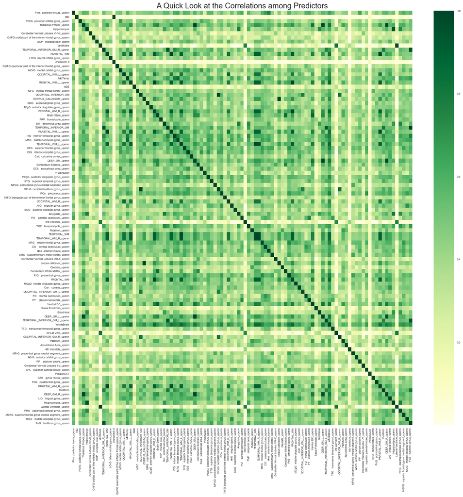

```python
plt.figure(figsize=(20,20))
sb.set(font_scale=0.7)
sb.heatmap(abs(df_1101_aver_corr),cmap="YlGn",annot=False)
plt.title("A Quick Look at the Correlations among Predictors",fontsize=20);
#plt.yticks([5.8,4.8,4.3,3.1,2,0.4],corr_mx.columns,fontsize=7)
```

### 3. Final Data Set

Since both the two processed Adnimerge and UPENN datasets above only include subjects’ first visit record, we can easily **merge the two datasets based on the unique RID (Participant roster ID)**.